# Dave’s Homework 1 Analysis

Reading in the restaurant data with the arules package.

```r
library(arules)
menu <- read.transactions("restaurantData.csv", sep = ",")
```

## Background

A restaurant owner has a core menu that has remained constant throughout the past two years, while many other dishes have rotated on and off the menu. The owner has prepared a dataset of all orders containing elements of that core menu in which the customer also ordered wine. The dataset has 3 columns: orderNumber which identifies each individual person’s order at a table, order which itemizes the order’s components, and type which provides the type of item in the order (takes one of 3 values: ‘Meat’, ‘Side’, ‘Wine’).

## Task

The restaurant owner would like to add wine suggestions to the menu next to each meat and analyze her customer ordering habits in general. She is also interested in showing a picture of a popular meal of hers in an ad in Gourmet Diner magazine. Your job is to address her interests and also to report anything else of interest in terms of customer ordering habits, all in a nice summary report that is complete but to the point.

#### Overview of the dataset

```r
str(menu)
```

```
Formal class 'transactions' [package "arules"] with 3 slots
  ..@ data       :Formal class 'ngCMatrix' [package "Matrix"] with 5 slots
  .. .. ..@ i       : int [1:80049] 8509 8510 8517 361 8506 8515 361 8505 8507 361 ...
  .. .. ..@ p       : int [1:26684] 0 3 6 9 12 15 18 21 24 27 ...
  .. .. ..@ Dim     : int [1:2] 8519 26683
  .. .. ..@ Dimnames:List of 2
  .. .. .. ..$ : NULL
  .. .. .. ..$ : NULL
  .. .. ..@ factors : list()
  ..@ itemInfo   :'data.frame': 8519 obs. of  1 variable:
  .. ..$ labels: chr [1:8519] "10004" "10023" "10025" "10040" ...
  ..@ itemsetInfo:'data.frame': 0 obs. of  0 variables
```

```r
summary(menu)
```

```
transactions as itemMatrix in sparse format with
 26683 rows (elements/itemsets/transactions) and
 8519 columns (items) and a density of 0.000352154

most frequent items:
                Meat                 Side                 Wine
                8894                 8894                 8894
     Pork Tenderloin Cantina Pinot Bianco              (Other)
                4902                 4818                43647

element (itemset/transaction) length distribution:
sizes
    3
26683

   Min. 1st Qu.  Median    Mean 3rd Qu.    Max.
      3       3       3       3       3       3

includes extended item information - examples:
  labels
1  10004
2  10023
3  10025
```

#### Looking at the first 25 observations

```r
inspect(menu[1:25])
```

```
     items
[1]  {order,orderNumber,type}
[2]  {14,Mashed Potatoes,Side}
[3]  {14,Filet Mignon,Meat}
[4]  {14,Blackstone Merlot,Wine}
[5]  {22,Mashed Potatoes,Side}
[6]  {22,Meat,Pork Tenderloin}
[7]  {22,Cantina Pinot Bianco,Wine}
[8]  {27,Mashed Potatoes,Side}
[9]  {27,Meat,Pork Tenderloin}
[10] {27,Cantina Pinot Bianco,Wine}
[11] {76,Mashed Potatoes,Side}
[12] {76,Meat,Pork Tenderloin}
[13] {76,Cantina Pinot Bianco,Wine}
[14] {115,Caesar Salad,Side}
[15] {115,Filet Mignon,Meat}
[16] {115,Meiomi Pinot Noir,Wine}
[17] {142,Caesar Salad,Side}
[18] {142,Filet Mignon,Meat}
[19] {142,Blackstone Merlot,Wine}
[20] {147,Caesar Salad,Side}
[21] {147,Meat,Roast Chicken}
[22] {147,Duckhorn Chardonnay,Wine}
[23] {160,Caesar Salad,Side}
[24] {160,Duck,Meat}
[25] {160,Duckhorn Chardonnay,Wine}
```

#### Frequency of items

```r
itemFrequency(trans[,1:3])
```

```
  Mashed Potatoes      Filet Mignon Blackstone Merlot
        0.1257795         0.1093070         0.1321332
```

#### Visualizing the frequencies

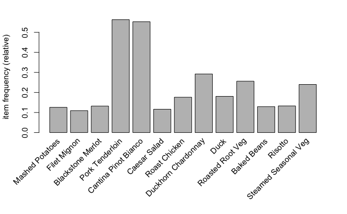

```r
itemFrequencyPlot(trans, support = 0.1)
```

[figure not shown]

```r
itemFrequencyPlot(trans, topN = 20 )
```

```r
image(menu[1:3])
```

[output not shown]

#### Learning the association rules from the dataset with default settings

```r
apriori(trans)
```

```
Apriori

Parameter specification:
 confidence minval smax arem  aval originalSupport maxtime support minlen maxlen target   ext
        0.8    0.1    1 none FALSE            TRUE       5     0.1      1     10  rules FALSE

Algorithmic control:
 filter tree heap memopt load sort verbose
    0.1 TRUE TRUE  FALSE TRUE    2    TRUE

Absolute minimum support count: 849

set item appearances ...[0 item(s)] done [0.00s].
set transactions ...[14 item(s), 8499 transaction(s)] done [0.00s].
sorting and recoding items ... [13 item(s)] done [0.00s].
creating transaction tree ... done [0.00s].
checking subsets of size 1 2 3 done [0.00s].
writing ... [7 rule(s)] done [0.00s].
creating S4 object  ... done [0.00s].
set of 7 rules
```

#### Setting the confidence levels and support to learn more rules

```r
rules <- apriori(menu, parameter = list(support = 0.006, confidence = 0.25, minlen = 2))
```

```
Apriori

Parameter specification:
 confidence minval smax arem  aval originalSupport maxtime support minlen maxlen
       0.25    0.1    1 none FALSE            TRUE       5   0.006      2     10
 target   ext
  rules FALSE

Algorithmic control:
 filter tree heap memopt load sort verbose
    0.1 TRUE TRUE  FALSE TRUE    2    TRUE

Absolute minimum support count: 160

set item appearances ...[0 item(s)] done [0.00s].
set transactions ...[8519 item(s), 26683 transaction(s)] done [0.03s].
sorting and recoding items ... [17 item(s)] done [0.00s].
creating transaction tree ... done [0.01s].
checking subsets of size 1 2 done [0.00s].
writing ... [18 rule(s)] done [0.00s].
creating S4 object  ... done [0.01s].
```

#### Checking out the rules

```r
summary(rules)
```

```
set of 18 rules

rule length distribution (lhs + rhs):sizes
 2
18

   Min. 1st Qu.  Median    Mean 3rd Qu.    Max.
      2       2       2       2       2       2

summary of quality measures:
    support          confidence          lift       count
 Min.   :0.01612   Min.   :0.2559   Min.   :3   Min.   : 430
 1st Qu.:0.04245   1st Qu.:1.0000   1st Qu.:3   1st Qu.:1133
 Median :0.06911   Median :1.0000   Median :3   Median :1844
 Mean   :0.08577   Mean   :0.8684   Mean   :3   Mean   :2288
 3rd Qu.:0.09425   3rd Qu.:1.0000   3rd Qu.:3   3rd Qu.:2515
 Max.   :0.18371   Max.   :1.0000   Max.   :3   Max.   :4902

mining info:
 data ntransactions support confidence
 menu         26683   0.006       0.25
```

#### 18 rules were discovered with parameter tweaks

```r
inspect(rules)
```

```
     lhs                       rhs                    support    confidence lift     count
[1]  {Meiomi Pinot Noir}    => {Wine}                 0.01611513 1.0000000  3.000112  430
[2]  {Filet Mignon}         => {Meat}                 0.03500356 1.0000000  3.000112  934
[3]  {Caesar Salad}         => {Side}                 0.03878874 1.0000000  3.000112 1035
[4]  {Mashed Potatoes}      => {Side}                 0.04219915 1.0000000  3.000112 1126
[5]  {Blackstone Merlot}    => {Wine}                 0.04238654 1.0000000  3.000112 1131
[6]  {Baked Beans}          => {Side}                 0.04264888 1.0000000  3.000112 1138
[7]  {Risotto}              => {Side}                 0.04429787 1.0000000  3.000112 1182
[8]  {Roast Chicken}        => {Meat}                 0.05647791 1.0000000  3.000112 1507
[9]  {Duck}                 => {Meat}                 0.05812690 1.0000000  3.000112 1551
[10] {Steamed Seasonal Veg} => {Side}                 0.08008845 1.0000000  3.000112 2137
[11] {Roasted Root Veg}     => {Side}                 0.08529776 1.0000000  3.000112 2276
[12] {Side}                 => {Roasted Root Veg}     0.08529776 0.2559029  3.000112 2276
[13] {Duckhorn Chardonnay}  => {Wine}                 0.09425477 1.0000000  3.000112 2515
[14] {Wine}                 => {Duckhorn Chardonnay}  0.09425477 0.2827749  3.000112 2515
[15] {Cantina Pinot Bianco} => {Wine}                 0.18056440 1.0000000  3.000112 4818
[16] {Wine}                 => {Cantina Pinot Bianco} 0.18056440 0.5417135  3.000112 4818
[17] {Pork Tenderloin}      => {Meat}                 0.18371248 1.0000000  3.000112 4902
[18] {Meat}                 => {Pork Tenderloin}      0.18371248 0.5511581  3.000112 4902
```

#### Looks like they were sorted by ascending support.

#### Inspecting with sort by lift.

```r
inspect(sort(rules, by = "lift"))
```

```
     lhs                       rhs                    support    confidence lift     count
[1]  {Wine}                 => {Cantina Pinot Bianco} 0.18056440 0.5417135  3.000112 4818
[2]  {Meat}                 => {Pork Tenderloin}      0.18371248 0.5511581  3.000112 4902
[3]  {Meiomi Pinot Noir}    => {Wine}                 0.01611513 1.0000000  3.000112  430
[4]  {Filet Mignon}         => {Meat}                 0.03500356 1.0000000  3.000112  934
[5]  {Caesar Salad}         => {Side}                 0.03878874 1.0000000  3.000112 1035
[6]  {Mashed Potatoes}      => {Side}                 0.04219915 1.0000000  3.000112 1126
[7]  {Blackstone Merlot}    => {Wine}                 0.04238654 1.0000000  3.000112 1131
[8]  {Baked Beans}          => {Side}                 0.04264888 1.0000000  3.000112 1138
[9]  {Risotto}              => {Side}                 0.04429787 1.0000000  3.000112 1182
[10] {Roast Chicken}        => {Meat}                 0.05647791 1.0000000  3.000112 1507
[11] {Duck}                 => {Meat}                 0.05812690 1.0000000  3.000112 1551
[12] {Steamed Seasonal Veg} => {Side}                 0.08008845 1.0000000  3.000112 2137
[13] {Roasted Root Veg}     => {Side}                 0.08529776 1.0000000  3.000112 2276
[14] {Side}                 => {Roasted Root Veg}     0.08529776 0.2559029  3.000112 2276
[15] {Duckhorn Chardonnay}  => {Wine}                 0.09425477 1.0000000  3.000112 2515
[16] {Wine}                 => {Duckhorn Chardonnay}  0.09425477 0.2827749  3.000112 2515
[17] {Cantina Pinot Bianco} => {Wine}                 0.18056440 1.0000000  3.000112 4818
[18] {Pork Tenderloin}      => {Meat}                 0.18371248 1.0000000  3.000112 4902
```

#### Find subset of rules for main courses

```r
mains_rules <- subset(rules, items %in% c("Filet Mignon", "Roast Chicken", "Duck", "Pork Tenderloin"))
inspect(mains_rules)
```

```
    lhs                  rhs               support    confidence lift     count
[1] {Filet Mignon}    => {Meat}            0.03500356 1.0000000  3.000112  934
[2] {Roast Chicken}   => {Meat}            0.05647791 1.0000000  3.000112 1507
[3] {Duck}            => {Meat}            0.05812690 1.0000000  3.000112 1551
[4] {Pork Tenderloin} => {Meat}            0.18371248 1.0000000  3.000112 4902
[5] {Meat}            => {Pork Tenderloin} 0.18371248 0.5511581  3.000112 4902
```